# Caduceus on Apple Silicon — research analysis

Profiles the MPS port of Caduceus across:

1. Setup & device
2. Load pretrained Ph + PS
3. Parameter breakdown (with weight-tying detection)
4. Inputs & encoding (tokenization → embedding lookup → RC-equivariant embedding for PS)
5. Forward outputs (logits, softmax heatmap, top-k decoded predictions, per-position entropy)
6. **Masked-LM accuracy** (top-1 / top-3, cross-entropy, perplexity, per-base confusion matrix)
7. Performance: wall-clock vs sequence length
8. Memory profile vs sequence length
9. Mamba dynamics: effective memory spectrum
10. dt and A_log structure across layers
11. Activation sparsity & dead channels
12. RC equivariance verification on Caduceus-PS
13. Suggested follow-ups

Run from the repo root: `jupyter notebook notebooks/caduceus_analysis.ipynb`. Models download on first run (~30 MB each).

## 1. Setup

```python
import sys
import time
from collections import defaultdict
from pathlib import Path

import numpy as np
import torch
import torch.nn.functional as F
import matplotlib.pyplot as plt

# Make the repo importable when running from notebooks/
sys.path.insert(0, str(Path.cwd().parent if Path.cwd().name == "notebooks" else Path.cwd()))

from caduceus.modeling_caduceus import CaduceusForMaskedLM, BiMambaWrapper
from caduceus.tokenization_caduceus import CaduceusTokenizer
from caduceus.mamba_pytorch import Mamba, Block, RMSNorm

device = torch.device("mps" if torch.backends.mps.is_available() else "cpu")
print(f"torch {torch.__version__}  device={device}")
```

```
torch 2.11.0  device=mps
```

## 2. Load pretrained Caduceus-Ph and Caduceus-PS

```python
PH_ID = "kuleshov-group/caduceus-ph_seqlen-131k_d_model-256_n_layer-16"
PS_ID = "kuleshov-group/caduceus-ps_seqlen-131k_d_model-256_n_layer-16"

ph = CaduceusForMaskedLM.from_pretrained(PH_ID, fused_add_norm=False).eval().to(device)
ps = CaduceusForMaskedLM.from_pretrained(PS_ID, fused_add_norm=False).eval().to(device)
tok = CaduceusTokenizer(model_max_length=131072)
print("loaded")
```

[output not shown]

```
loaded
```

## 3. Parameter breakdown

Caduceus has weight-tied parameters (`mamba_rev.in_proj`/`out_proj` share storage with `mamba_fwd` when `bidirectional_weight_tie=True`). PyTorch's `parameters()` iterator deduplicates by tensor identity, so `unique_params` reflects the real footprint. The breakdown below groups by component.

```python
def param_breakdown(model, name):
    by_kind = defaultdict(int)
    seen_ptrs = set()
    for full_name, p in model.named_parameters():
        # Bucket by the last component-name segment we care about
        if ".embeddings." in full_name:
            bucket = "embedding"
        elif ".lm_head" in full_name:
            bucket = "lm_head"
        elif "norm_f" in full_name:
            bucket = "final_norm"
        elif ".norm." in full_name or full_name.endswith(".norm.weight"):
            bucket = "per_layer_norm"
        elif "mamba_fwd" in full_name:
            bucket = "mamba_fwd"
        elif "mamba_rev" in full_name:
            bucket = "mamba_rev_unique"
        else:
            bucket = "other"
        # Only count each unique tensor once
        ptr = p.data_ptr()
        if ptr in seen_ptrs:
            continue
        seen_ptrs.add(ptr)
        by_kind[bucket] += p.numel()
    total = sum(by_kind.values())
    print(f"\n{name}: {total:,} unique params, {total*4/1e6:.1f} MB fp32")
    for k, v in sorted(by_kind.items(), key=lambda x: -x[1]):
        print(f"  {k:25s}  {v:>10,}  ({v/total*100:4.1f}%)")
    return by_kind

_ = param_breakdown(ph, "Caduceus-Ph")
_ = param_breakdown(ps, "Caduceus-PS")
```

```
Caduceus-Ph: 7,725,312 unique params, 30.9 MB fp32
  mamba_fwd                   7,004,160  (90.7%)
  mamba_rev_unique              712,704  ( 9.2%)
  embedding                       4,096  ( 0.1%)
  per_layer_norm                  4,096  ( 0.1%)
  final_norm                        256  ( 0.0%)

Caduceus-PS: 7,725,312 unique params, 30.9 MB fp32
  mamba_fwd                   7,004,160  (90.7%)
  mamba_rev_unique              712,704  ( 9.2%)
  embedding                       4,096  ( 0.1%)
  per_layer_norm                  4,096  ( 0.1%)
  final_norm                        256  ( 0.0%)
```

## 4. Inputs & encoding

A DNA sequence reaches the model in two stages:

1. **Char → token id (tokenization).** 16-token vocab: 7 special tokens (`[CLS]`, `[SEP]`, `[BOS]`, `[MASK]`, `[PAD]`, `[RESERVED]`, `[UNK]`) + the five nucleotides A, C, G, T, N. The complement map sends A↔T (7↔10), C↔G (8↔9), N→N — used by Caduceus-PS for reverse-complement equivariance.
2. **Token id → embedding vector.** A learned lookup table of shape `(vocab_size, d_model)`. Caduceus-Ph uses a vanilla `nn.Embedding`. Caduceus-PS uses an `RCPSEmbedding` that constructs the embedding so `embed(rc(x))` is the **flipped reverse-complement** of `embed(x)` — RC equivariance is baked into the encoding step itself.

```python
# --- Stage 1: tokenization (char -> token id) ---
print("vocab (token -> id):")
for s, i in sorted(tok._vocab_str_to_int.items(), key=lambda x: x[1]):
    print(f"  {i:>3d}  {s!r}")
print("\ncomplement_map (Ph & PS share the same map):")
print(" ", {int(k): v for k, v in ph.config.complement_map.items()})

seq = "ACGTTACCGGAATTACGT" * 8  # 144 nt, deliberately not its own reverse complement
ids = torch.tensor([tok(seq)["input_ids"]], dtype=torch.long).to(device)

print(f"\ninput sequence (first 24 chars): {seq[:24]!r}")
print(f"tokenized shape: {tuple(ids.shape)}  (B=1, L includes a leading [CLS])")
print(f"first 24 token ids: {ids[0, :24].cpu().tolist()}")
print("\nchar  ->  id  (first 12 positions, after CLS):")
inv_vocab = {v: k for k, v in tok._vocab_str_to_int.items()}
for pos, tid in enumerate(ids[0, :13].cpu().tolist()):
    if pos == 0:
        print(f"  pos {pos:>3d}  [CLS]  -> {tid}")
    else:
        print(f"  pos {pos:>3d}    {seq[pos-1]}    -> {tid}  ({inv_vocab[tid]!r})")
```

```
vocab (token -> id):
    0  '[CLS]'
    1  '[SEP]'
    2  '[BOS]'
    3  '[MASK]'
    4  '[PAD]'
    5  '[RESERVED]'
    6  '[UNK]'
    7  'A'
    8  'C'
    9  'G'
   10  'T'
   11  'N'

complement_map (Ph & PS share the same map):
  {0: 0, 1: 1, 2: 2, 3: 3, 4: 4, 5: 5, 6: 6, 7: 10, 8: 9, 9: 8, 10: 7, 11: 11, 12: 12, 13: 13, 14: 14, 15: 15}

input sequence (first 24 chars): 'ACGTTACCGGAATTACGTACGTTA'
tokenized shape: (1, 145)  (B=1, L includes a leading [CLS])
first 24 token ids: [7, 8, 9, 10, 10, 7, 8, 8, 9, 9, 7, 7, 10, 10, 7, 8, 9, 10, 7, 8, 9, 10, 10, 7]

char  ->  id  (first 12 positions, after CLS):
  pos   0  [CLS]  -> 7
  pos   1    A    -> 8  ('C')
  pos   2    C    -> 9  ('G')
  pos   3    G    -> 10  ('T')
  pos   4    T    -> 10  ('T')
  pos   5    T    -> 7  ('A')
  pos   6    A    -> 8  ('C')
  pos   7    C    -> 8  ('C')
  pos   8    C    -> 9  ('G')
  pos   9    G    -> 9  ('G')
  pos  10    G    -> 7  ('A')
  pos  11    A    -> 7  ('A')
  pos  12    A    -> 10  ('T')
```

```python
# --- Stage 2a: token id -> embedding vector (Caduceus-Ph, vanilla nn.Embedding) ---
emb_layer = ph.caduceus.backbone.embeddings.word_embeddings
print(f"Caduceus-Ph embedding table: {tuple(emb_layer.weight.shape)}  "
      f"(vocab_size={ph.config.vocab_size}, d_model={ph.config.d_model})")

with torch.no_grad():
    embeds_ph = emb_layer(ids)                        # (1, L, d_model)
print(f"\ninputs (ids):     shape={tuple(ids.shape)}      dtype={ids.dtype}")
print(f"embeddings (Ph):  shape={tuple(embeds_ph.shape)}  dtype={embeds_ph.dtype}")
print(f"  -> per-position vector norm range: "
      f"[{embeds_ph.norm(dim=-1).min().item():.3f}, {embeds_ph.norm(dim=-1).max().item():.3f}]")

# Show the embeddings of A/C/G/T as compact vectors, then the cosine similarity matrix
acgt_ids = [tok._vocab_str_to_int[c] for c in "ACGT"]
acgt_emb = emb_layer.weight[acgt_ids].detach().cpu()
sims = F.cosine_similarity(acgt_emb.unsqueeze(0), acgt_emb.unsqueeze(1), dim=-1).numpy()
print(f"\nA/C/G/T embedding cosine similarity (Caduceus-Ph):")
print("       " + "  ".join(f"{c:>6}" for c in "ACGT"))
for i, c in enumerate("ACGT"):
    print(f"  {c}  " + "  ".join(f"{sims[i, j]:>6.3f}" for j in range(4)))
```

```
Caduceus-Ph embedding table: (16, 256)  (vocab_size=16, d_model=256)

inputs (ids):     shape=(1, 145)      dtype=torch.int64
embeddings (Ph):  shape=(1, 145, 256)  dtype=torch.float32
  -> per-position vector norm range: [6.388, 9.374]

A/C/G/T embedding cosine similarity (Caduceus-Ph):
            A       C       G       T
  A   1.000   0.146   0.260   0.136
  C   0.146   1.000   0.160   0.298
  G   0.260   0.160   1.000   0.097
  T   0.136   0.298   0.097   1.000
```

```python
# --- Stage 2b: PS RC-equivariant encoding ---
# RCPSEmbedding builds a (B, L, 2*d_model) embedding such that
#   embed(rc(x)) = flip(embed(x), dims=[L, channel])
# That property propagates through every layer and is what gives Caduceus-PS
# its by-construction RC equivariance. Verify it numerically here.

cmap = {int(k): v for k, v in ps.config.complement_map.items()}
rc_ids = torch.tensor(
    [[cmap[t] for t in ids[0].tolist()][::-1]],
    dtype=torch.long, device=device,
)

ps_emb_layer = ps.caduceus.backbone.embeddings.word_embeddings
print(f"PS RCPSEmbedding internal table: {tuple(ps_emb_layer.embedding.weight.shape)}")
print(f"PS RCPSEmbedding output (per RCPS construction):  (B, L, 2 * d_model)")

with torch.no_grad():
    e_x = ps_emb_layer(ids)                           # (1, L, 2*d_model)
    e_rc = ps_emb_layer(rc_ids)
    # The RCPS property: embed(rc(x)) == flip(embed(x), dims=[L, channel])
    e_x_flipped = torch.flip(e_x, dims=[-2, -1])
    diff = (e_rc - e_x_flipped).abs().max().item()

print(f"\nembed(rc(x)) shape:  {tuple(e_rc.shape)}")
print(f"flip(embed(x))[L,C]: {tuple(e_x_flipped.shape)}")
print(f"max abs diff: {diff:.2e}   (architectural — must be ~0)")
assert diff < 1e-6, "RC-equivariant embedding property is broken"
print("=> RC-equivariance is enforced at the embedding step itself.")
```

```
PS RCPSEmbedding internal table: (16, 256)
PS RCPSEmbedding output (per RCPS construction):  (B, L, 2 * d_model)

embed(rc(x)) shape:  (1, 145, 512)
flip(embed(x))[L,C]: (1, 145, 512)
max abs diff: 0.00e+00   (architectural — must be ~0)
=> RC-equivariance is enforced at the embedding step itself.
```

## 5. Forward pass — outputs

The model returns logits over the 16-token vocab at every input position: shape `(B, L, vocab_size)`. We look at:

1. The shape, value range, and top-1 token recovery at unmasked positions.
2. A softmax heatmap to see where the model is confident vs. uniform.
3. Top-3 decoded predictions per position (with probabilities) for the first stretch of the sequence.
4. Per-position entropy — *where is the model uncertain?*

```python
with torch.no_grad():
    out_ph = ph(ids).logits
    out_ps = ps(ids).logits

for name, logits in [("Caduceus-Ph", out_ph), ("Caduceus-PS", out_ps)]:
    top1 = logits[0].argmax(dim=-1)
    matches = (top1[1:] == ids[0, 1:]).sum().item()
    print(f"{name}: shape={tuple(logits.shape)}  range=[{logits.min().item():.2f}, {logits.max().item():.2f}]  top-1 recovery {matches}/{ids.shape[1]-1}")
```

```
Caduceus-Ph: shape=(1, 145, 16)  range=[-29.35, 6.29]  top-1 recovery 143/144
Caduceus-PS: shape=(1, 145, 16)  range=[-56.15, 6.29]  top-1 recovery 105/144
```

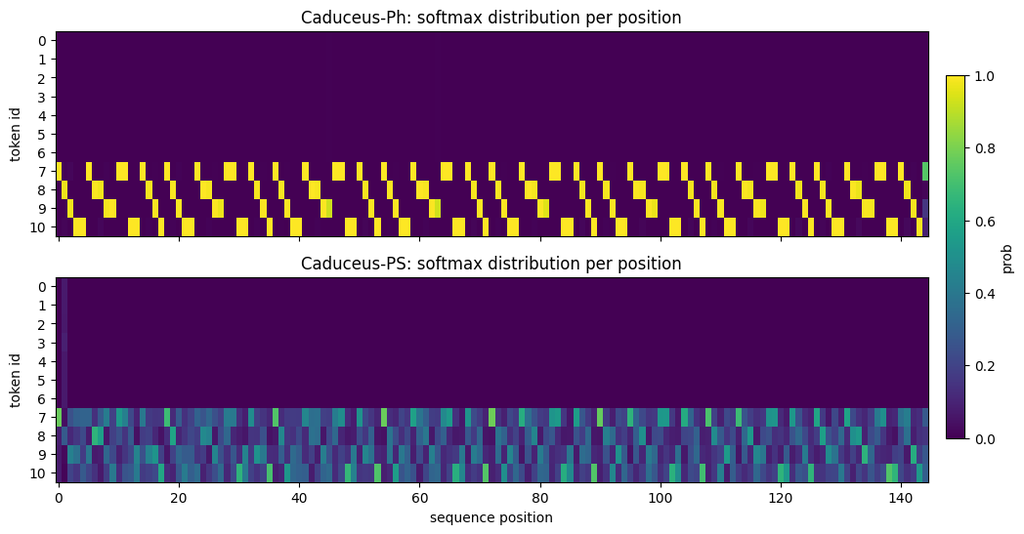

```python
fig, axes = plt.subplots(2, 1, figsize=(12, 6), sharex=True)
for ax, (name, logits) in zip(axes, [("Caduceus-Ph", out_ph), ("Caduceus-PS", out_ps)]):
    probs = F.softmax(logits[0], dim=-1).cpu().numpy()
    # Show the 11 "interesting" tokens (drop padding/reserved at the tail)
    im = ax.imshow(probs[:, :11].T, aspect="auto", cmap="viridis", vmin=0, vmax=1)
    ax.set_yticks(range(11))
    ax.set_yticklabels([f"{i}" for i in range(11)])
    ax.set_ylabel("token id")
    ax.set_title(f"{name}: softmax distribution per position")
axes[-1].set_xlabel("sequence position")
fig.colorbar(im, ax=axes, fraction=0.02, pad=0.02, label="prob")
plt.show()
```

```
pos  input  top-3 (token  prob)                                entropy
  0      A      A(1.00)      G(0.00)      C(0.00)                0.034
  1      C      C(0.97)      T(0.01)      A(0.01)                0.142
  2      G      G(0.98)      A(0.02)      C(0.00)                0.113
  3      T      T(1.00)      C(0.00)      G(0.00)                0.015
  4      T      T(1.00)      C(0.00)      A(0.00)                0.023
  5      A      A(1.00)      G(0.00)      C(0.00)                0.016
  6      C      C(0.99)      T(0.00)      A(0.00)                0.039
  7      C      C(0.98)      T(0.02)      A(0.00)                0.123
  8      G      G(0.99)      A(0.01)      T(0.00)                0.084
  9      G      G(1.00)      A(0.00)      T(0.00)                0.022
 10      A      A(1.00)      G(0.00)      C(0.00)                0.017
 11      A      A(1.00)      G(0.00)      T(0.00)                0.016
 12      T      T(1.00)      C(0.00)      A(0.00)                0.017
 13      T      T(1.00)      C(0.00)      G(0.00)                0.016
 14      A      A(1.00)      G(0.00)      C(0.00)                0.012
 15      C      C(0.99)      T(0.01)      G(0.00)                0.076
```

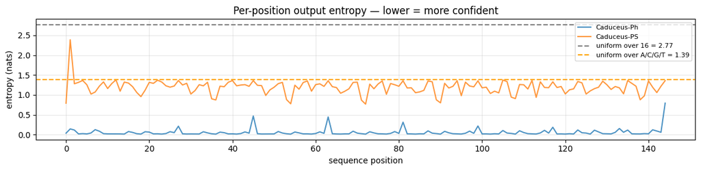

```python
# Top-3 decoded predictions per position + per-position entropy.
inv_vocab_full = {v: k for k, v in tok._vocab_str_to_int.items()}
n_show = 16  # first n_show positions of the un-masked forward pass

print(f"{'pos':>3}  {'input':>5}  {'top-3 (token  prob)':<48}  {'entropy':>8}")
probs_ph = F.softmax(out_ph[0], dim=-1)
for pos in range(n_show):
    input_tok = inv_vocab_full[ids[0, pos].item()]
    top3 = probs_ph[pos].topk(3)
    top3_str = "  ".join(
        f"{inv_vocab_full[t.item()]:>5}({p.item():.2f})" for p, t in zip(top3.values, top3.indices)
    )
    H = -(probs_ph[pos] * (probs_ph[pos].clamp_min(1e-12)).log()).sum().item()
    print(f"{pos:>3}  {input_tok:>5}  {top3_str:<48}  {H:>8.3f}")

# Per-position entropy line (tells you where the model is confident vs. uncertain)
entropy_ph = -(probs_ph * probs_ph.clamp_min(1e-12).log()).sum(dim=-1).cpu().numpy()
probs_ps = F.softmax(out_ps[0], dim=-1)
entropy_ps = -(probs_ps * probs_ps.clamp_min(1e-12).log()).sum(dim=-1).cpu().numpy()
plt.figure(figsize=(12, 3))
plt.plot(entropy_ph, label="Caduceus-Ph", alpha=0.8)
plt.plot(entropy_ps, label="Caduceus-PS", alpha=0.8)
plt.axhline(np.log(16), color="gray", linestyle="--", label=f"uniform over 16 = {np.log(16):.2f}")
plt.axhline(np.log(4), color="orange", linestyle="--", label=f"uniform over A/C/G/T = {np.log(4):.2f}")
plt.xlabel("sequence position")
plt.ylabel("entropy (nats)")
plt.title("Per-position output entropy — lower = more confident")
plt.legend(loc="upper right", fontsize=8)
plt.grid(True, alpha=0.3)
plt.tight_layout()
plt.show()
```